# Analysis of the Results of Metadynamics Simulations by metadynminer and metadynminer3d

Molecular simulations solve the equation of motion of molecular systems, making the 3D shapes of molecules four-dimensional by adding the time coordinate. These methods have great potential in drug discovery because they can realistically model the structures of protein molecules targeted by drugs, as well as the process of binding of a potential drug to its molecular target. However, routine application of biomolecular simulations is hampered by the very high computational costs of this method. Several methods have been developed to address this problem. One of them, metadynamics, disfavors states of the simulated system that have been already visited and thus forces the system to explore new states. Here we present the package metadynminer and metadynminer3d to analyze and visualize results from metadynamics, in particular those produced by a popular metadynamics package Plumed.

Dalibor Trapl (Department of Biochemistry and Microbiology, University of Chemistry and Technology, Prague) , Vojtech Spiwok (Department of Biochemistry and Microbiology, University of Chemistry and Technology, Prague)  
2022-12-20

# 1 Introduction

Molecular simulations and their pioneers Martin Karplus, Michael Levitt, and Arieh Warshel have been awarded the Nobel Prize in 2013 (Karplus 2013). Their methods, in particular the method of molecular dynamics simulation, computationally simulate the motions of atoms in a molecular system. A simulation starts from a molecular system defined by positions (Cartesian coordinates) of the individual atoms. The heart of the method is in a calculation of forces acting on individual atoms and their numerical integration in the spirit of Newtonian dynamics, i.e., the conversion of a force vector to an acceleration vector, then velocity vector and, finally, to a new position of an atom. By repeating these steps, it is possible to reconstruct a record of atomic motions known as a trajectory.

Molecular simulations have great potential in drug discovery. A molecule of drug influences (enhances or blocks) the function of some biomolecule in the patient’s body, typically a receptor, enzyme or other protein. These molecules are called drug targets. The process of design for a new drug can be significantly accelerated with knowledge of the 3D structure (Cartesian coordinates of atoms) of the target. With such knowledge, it is possible to find a “druggable” cavity in the target and a molecule that fits and favorably binds to this cavity to influence its function. Strong binding implies that the drug influences the target even in low doses, hence does not cause side effects by interacting with unwanted targets.

Experimental determination of the 3D structures of proteins and other biomolecules is a very expensive and laborious process. Molecular simulations can, at least in principle, replace such expensive and laborious experiments by computing. In principle, a molecular simulation starting from virtually any 3D shape of a molecule would end up in energetically the most favorable shape. This is analogous with water flowing from mountains to valleys and not in the opposite way.

Unfortunately, this approach is extremely computationally expensive. The integration step of a simulation must be small enough to comprise the fastest motions in the molecular system. In practical simulations, it is necessary to use femtosecond integration steps. This means that it is necessary to carry out thousands of steps to simulate picoseconds, millions of steps to simulate nanoseconds, and so forth. In each step, it is necessary to evaluate a substantial number of interactions between atoms. As a result, it is possible to routinely simulate nano- to microseconds. Longer simulations require special high-performance computing resources.

Protein folding, i.e., the transition from a quasi-random to the biologically relevant 3D structure, takes place in microseconds for very small proteins and in much longer time scales for pharmaceutically interesting proteins. For this reason, prediction of a 3D structure by molecular simulations is limited to few small and fast folding proteins. For large proteins, it is currently impossible or at least far from being routine.

Several methods have been developed to address this problem. Metadynamics (Laio and Parrinello 2002) uses artificial forces to force the system to explore states that have not been previously explored in the simulation. At the beginning of the simulation, it is necessary to chose some parameters of the system referred to as collective variables. For example, numerically expressed compactness of the protein can be used as a collective variable to accelerate its folding from a noncompact to a compact 3D structure. Metadynamics starts as a usual simulation. After a certain number of steps (typically 500), the values of the collective variables are calculated and from this moment this state becomes slightly energetically disfavored due to the addition of an artificial bias potential in the shape of a Gaussian hill. After another 500 steps, another hill is added to the bias potential and so forth. These Gaussian hills accumulate until they “flood” some energy minimum and help the system to escape this minimum and explore various other states (Figure 1). In the analogy of water floating from mountains to valleys, metadynamics adds “sand” to fill valleys to make water flow from valleys back to mountains. This makes the simulation significantly more efficient compared to a conventional simulation because the “water” does not get stuck anywhere.

Using the application of metadynamics, it is possible to significantly accelerate the process of folding. Hopefully, by the end of metadynamics we can see folded, unfolded, and many other states of the protein. However, the interpretation of the trajectory is not straightforward. In standard molecular dynamics simulation (without metadynamics), the state which is the most populated is the most populated in reality. This is not true anymore with metadynamics.

Packages metadynminer and metadynminer3d use the results of metadynamics simulations to calculate the free energy surface of the molecular system. The most favored states (states most populated in reality) correspond to minima on the free energy surface. The state with the lowest free energy is the most populated state in the reality, i.e., the folded 3D structure of the protein.

As an example to illustrate metadynamics and our package, we use an ultrasimple molecule of “alanine dipeptide” (Figure 1). This molecule can be viewed as a “protein” with just one amino acid residue (real proteins have hundreds or thousands of amino acid residues). As a collective variable it is possible to use an angle $\phi$ defined by four atoms. Biasing of this collective variable accelerates a slow rotation around the corresponding bond. Figure 1 shows the free energy surface of alanine dipeptide as the black thick line. It is not known before the simulation. The simulation starts from the state B. After 500 simulation steps, the hill is added (the hill is depicted as the red line, the flooding potential (“sand”) at the top, the free energy surface with added flooding potential at the bottom). The sum of 1, 10, 100, 200, 500, and 700 hills are depicted as red to blue lines.

At the end of simulation the free energy surface is relatively well flattened (blue line in Fig. 1 bottom). Therefore, the free energy surface can be estimated as a negative imprint of added “sand”:

$$\begin{equation}
G(s) = -kT \log(P(s)) = -V(s) = \sum_i w_i \exp(-(s-S_i)^2/{2 \sigma^2}),
\tag{1}
\end{equation}$$

where $G$, $V$, and $P$ are free energy, metadynamics bias (flooding) potential, and probability, respectively, of a state with a collective variable $s$, $k$ is Boltzmann constant, $T$ is temperature in Kelvins, $w_i$ is height, $S_i$ is position and $\sigma_i$ is width of each hill. The equation can be easily generalized for two or more collective variables.

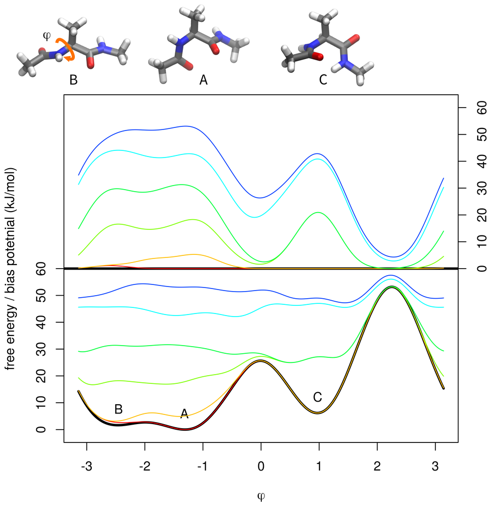

Figure 1: Metadynamics simulation of alanine dipeptide. Dihedral angle $\phi$ was used as the collective variable. The top part shows molecular structures of three free energy minima (stable structures) differing in the value of $\phi$. According to metadynamics prediction, A is the global minimum (free energy 0 kJ/mol) and B and C are local minima (1.5 and 6.3 kJ/mol, respectively). According to Equation 1, this corresponds to probabilities 0.61, 0.34, and 0.05 for A, B, and C, respectively. The middle part shows the bias potential (scaled by $(T+\Delta T)/\Delta T$) after addition of 1, 10, 100, 200, 500, and 700 hills (colors from red to blue). The bottom part shows the accurate free energy surface calculated by metadynamics with 30,000 hills (black) flooded by 1, 10, 100, 200, 500, and 700 hills (colors from red to blue). The figure was generated by metadynminer except for molecular structures and final assembly.

The original version of metadynamics was developed with constant heights of Gaussian hills. Later, a so-called well-tempered metadynamics was developed (Barducci et al. 2007), which uses decreasing hill heights to improve the accuracy of the results. This requires modification of the equation:

$$\begin{equation}
G(s) = -kT \log(P(s)) = - \frac{T + \Delta T}{\Delta T} V(s) =
- \frac{T + \Delta T}{\Delta T} \sum_i w_i \exp(-(s-S_i)^2/{2 \sigma^2}),
\tag{2}
\end{equation}$$

where $\Delta T$ an input parameter with the dimension of temperature (zero for unbiased simulation and infinity for the original metadynamics with constant hill heights). Nowadays, the vast majority of metadynamics applications use the well-tempered metadynamics algorithm for better convergence towards an accurate free energy surface prediction.

There are numerous packages for molecular simulations such as Amber (Weiner and Kollman 1981), Gromacs (Abraham et al. 2015), Gromos (Christen et al. 2005), NAMD (Phillips et al. 2020), CHARMM (Brooks et al. 2009), Acemd (Harvey et al. 2009), and others. These packages are primarily developed for basic unbiased simulations with no or very limited support of metadynamics. Plumed software (Tribello et al. 2014) has been developed to introduce metadynamics into various simulation programs. Since its introduction, Plumed articles have been cited in more than thousand papers from drug design, molecular biology, material sciences, and other fields. The R package metadynminer was developed for analysis and visualization of the results from Plumed. With a simple file conversion script, it can be used also with other simulation programs that support metadynamics.

# 2 Example of usage

The package metadynminer will be presented on a bias potential from a 30 ns (30,000 hills) simulation of alanine dipeptide (Figure 1). Two rotatable bonds of the molecule, referred to as $\phi$ and $\psi$, were used as collective variables. This is basically an expansion of the free energy surface in Figure 1 to two dimensions. Hills from simulations with two collective variables ($\phi$ and $\psi$) and with one collective variable ($\phi$) are provided in metadynminer as `acealanme` and `acealanme1d`, respectively. metadynminer3d was developed for analysis of metadynamics with three collective variables. It contains a sample data `acealanmed3`, with collective variables $\phi$, $\psi$ and $\omega$. We decided to distribute metadynminer and metadynminer3d separately, because of the use of different visualization tools and to keep the size of packages low. Metadynamics simulations with 1-3 collective variables comprise almost all metadynamics applications nowadays (not considering special metadynamics variants).

Hills file generated by Plumed package (filename HILLS) can be loaded to R by the function `read.hills`:

```
  hillsfile <- read.hills("HILLS.txt", per=c(TRUE, TRUE))
```

The parameter `per` indicates periodicity of the collective variable (dihedral angles are periodic, i.e., $+\pi \simeq -\pi$). For the simulation described above, `hillsfile` is identical to `acealanme` already contained in metadynminer as an example.

Typing the name `hillsfile` will return its dimensionality (the number of collective variables) and the number of hills. A hills object can be plotted:

```
  plot(hillsfile, xlab="phi", ylab="psi", pch=19, cex=0.5, col=gray(0, 0.1))
```

For metadynamics with one collective variable, it plots its evolution. For metadynamics with two or three collective variables, it plots a scatter plot of collective variables number 1 vs. 2 or 1 vs. 2 vs. 3, respectively (Figure 2).

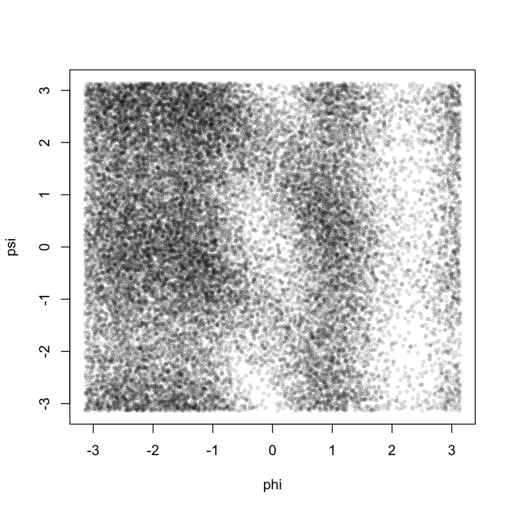

Figure 2: Scatter plot of hills position. Each point in the plot represents a single hill in the space of collective variable coordinates. This helps to assess which states of the system were sampled.

In well-tempered metadynamics it may be interesting to see the evolution of hill heights ($w_i$ in Equation (2)). This can be plotted (Figure 3) by typing:

```
  plotheights(hillsfile)
```

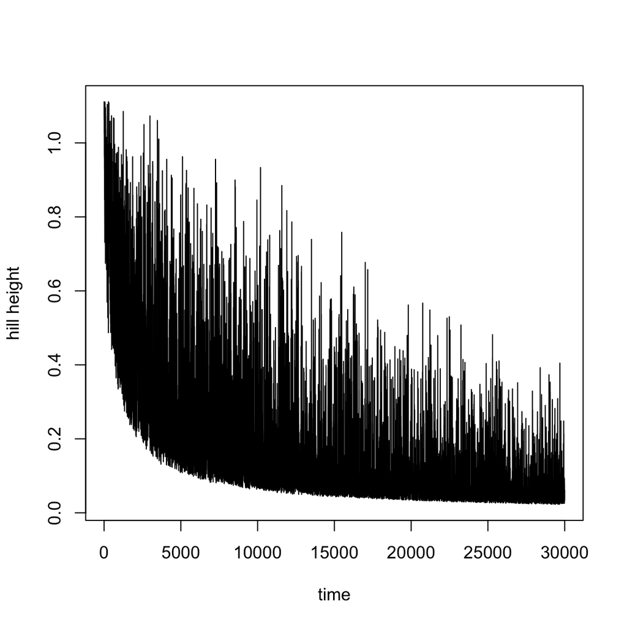

Figure 3: Evolution of heights of hills in metadynamics plotted by function plotheights. In well-tempered metadynamics, heights of hills decrease with the progress of flooding of free energy minima. The evolution of heights of hills may help to assess the completeness of flooding.

Addition operation is available for hillsfile object. For example, multiple hills files can be concatenated.

Next, the user can sum negative values of all hills to make the free energy surface estimate by typing:

```
  fesurface <- fes(hillsfile)
```

Hills files from well-tempered metadynamics are prescaled by $(\Delta T + T)/\Delta T$ when printed by Plumed, so no special action is required in metadynminer. The function `fes` uses the Bias Sum algorithm (Hošek and Spiwok 2016). This function is fast because instead of evaluation of Gaussian function for every hill, it uses a precomputed Gaussian hill that is relocated to hill centers. It is also fast because it was implemented in C++ via Rcpp. Because of approximations used in the function `fes`, this function should be used for visualization purposes. For detailed analysis of a free energy surface, we advise to use a slow but accurate `fes2` function. This function explicitly evaluates Gaussian function for every hill. It can be also used for (rarely used) metadynamics with variable hill widths.

Typing the name of the variable with a free energy surface returns its dimensionality, number of points, and free energy maximum and minimum. The same is returned by `summary` function. It is possible to add and subtract two free energy surfaces with the same number of grid points. The functions `min` and `max` can be used as well to calculate minimum or maximum. It is also possible to multiply or divide the free energy surface by a constant (for example, to convert kJ to kcal and vice versa). Free energy surface can be plotted (Figure 4) by typing:

```
  plot(fesurface, xlab="phi", ylab="psi")
```

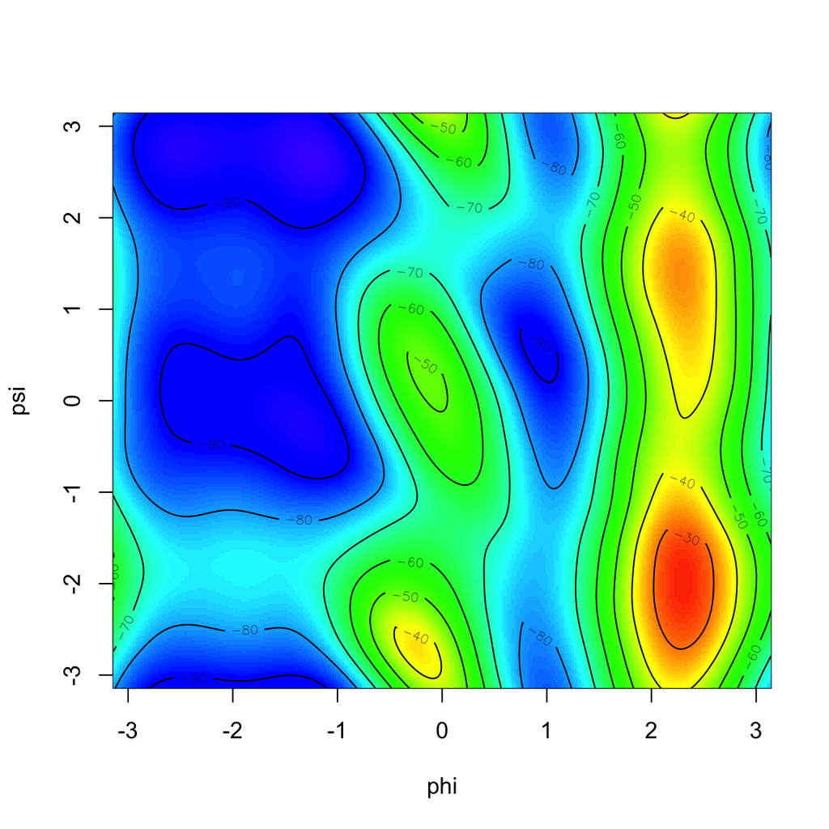

Figure 4: Free energy surface. Minima (blue colors) represent stable states with high abundance, whereas regions with high free energy correspond to low abundance states.

In metadynamics simulation, it is important to find free energy minima. The global minimum refers to the most favored state of the system (i.e., the state with the highest probability). Other local minima correspond to metastable states. The user can find free energy minima by typing:

```
  minima <- fesminima(fesurface)
```

This function locates minima using a simple algorithm. The free energy surface is separated into 8, 8x8, or 8x8x8 bins (for 1D, 2D, or 3D surface, respectively). The minimum in each bin is located. Next, the program tests whether the minimum is a local minimum of the whole free energy surface. The number of grid points can be changed by `ngrid` parameter. Typing the name of the minima variable will return the table of minima (denoted as A, B, C, … in the order of their free energies), their collective variables, and free energy values.

In addition, the function summary provides populations of each minimum calculated as:
$$\begin{equation}
P_{i,rel} = \exp(-G_i/kT),
\end{equation}$$
$$\begin{equation}
P_i = P_{i,rel} / \sum (P_{j,rel}).
\end{equation}$$

```
  letter CV1bin CV2bin        CV1        CV2 free_energy relative_pop
1      A     78    236 -1.2443171  2.6487938   -97.26095 8.614856e+16
2      B     28    240 -2.4763142  2.7473536   -95.63038 4.480527e+16
3      C     74    118 -1.3428769 -0.2587194   -94.73163 3.124915e+16
4      D    166    151  0.9239978  0.5543987   -91.66626 9.143024e+15
5      E    170    251  1.0225576  3.0183929   -84.37799 4.920882e+14
         pop
1 50.1335658
2 26.0741201
3 18.1852268
4  5.3207200
5  0.2863674
```

Using the plot function on a `fesminima` output provides the same plot as for `fes` output with additional letters indicating minima (Figure 5).

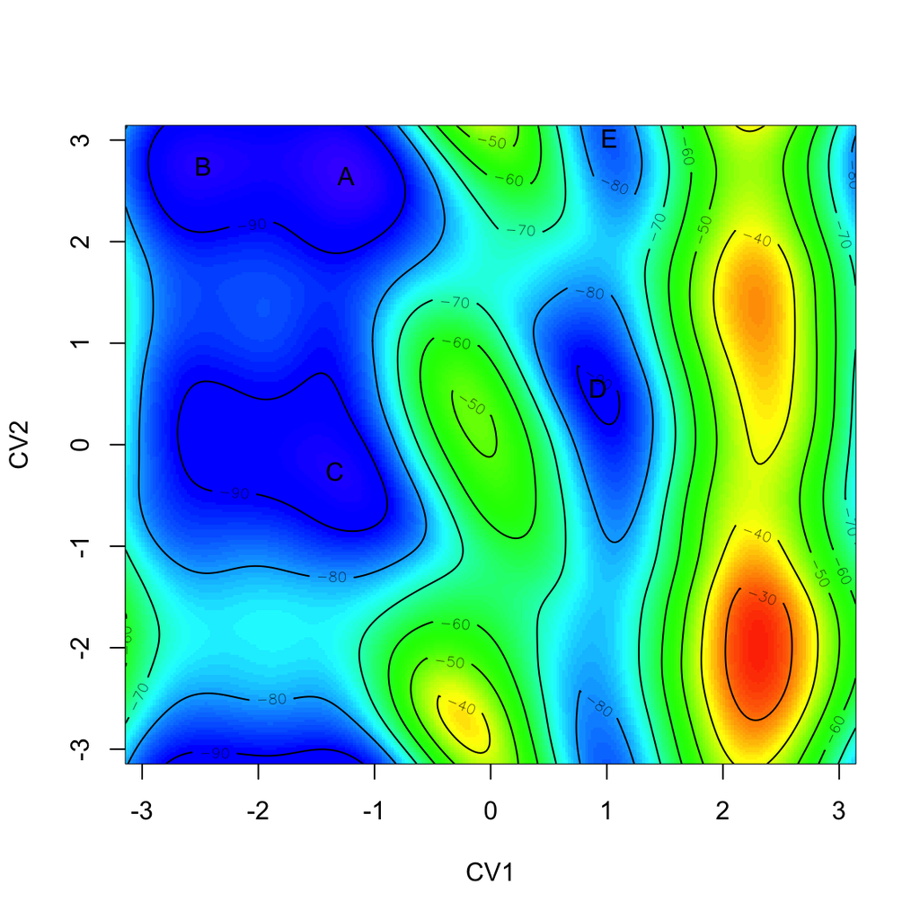

Figure 5: Free energy surface with indicated free energy minima A-E. The minimum A is the most abundant state, minima B-E are metastable states.

It is essential to evaluate the accuracy of metadynamics and to decide when the simulation is accurate enough so that it can be stopped. For this purpose, it is useful to look at the evolution of relative free energies. The relative free energies (for example, the free energy difference of minima A and C) evolve rapidly at the beginning of the simulation, and with the progress of the simulation, their difference is converging towards the real free energy difference. Function `feprof` calculates the evolution of free energy differences from the global minimum (global at the end of the simulation). It can be used as:

```
  prof <- feprof(minima)
```

Function summary provides minima and maxima of these free energy differences. The evolution can be plotted (Figure 6) by typing:

```
  plot(prof)
```

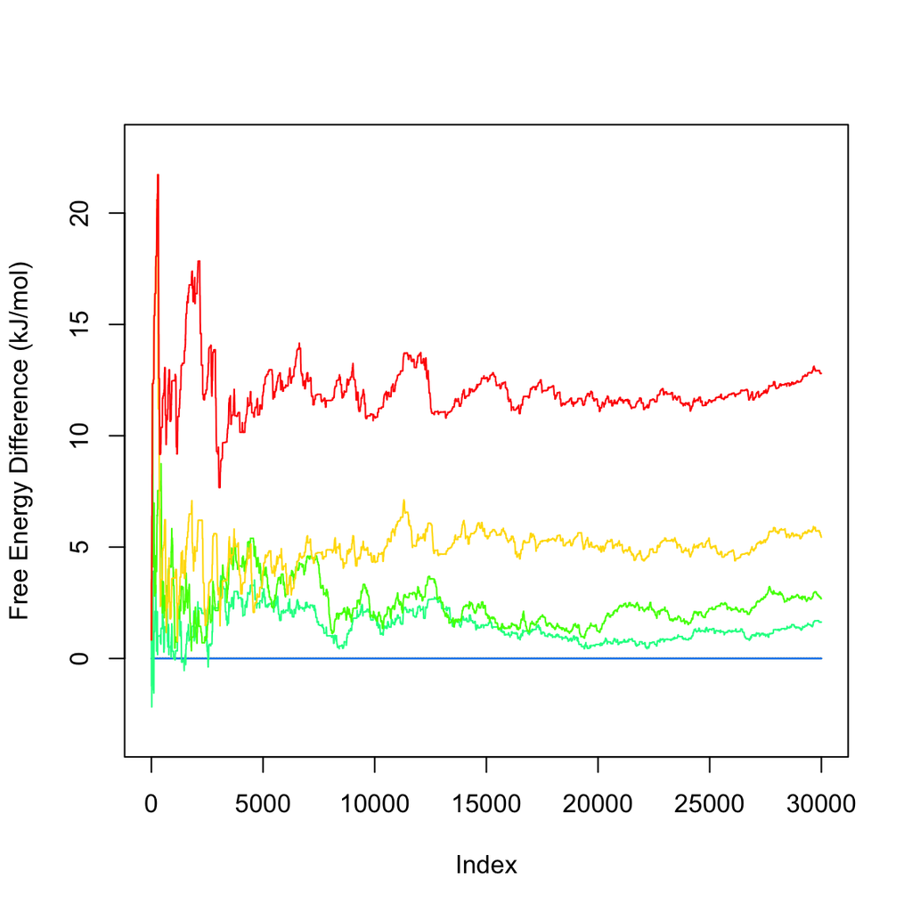

Figure 6: Evolution of free energy differences. The free energy differences of minima B-E (relative to the global minimum A) converge to the exact free energy differences with the progress of the simulation. This plot helps to assess the accuracy of the predicted free energy differences.

Beside minima, another important points on the free energy surface are transition states. Change of the molecular structure from one minimum to another takes place via a path with the lowest energy demand. The state with the highest energy along this path is called the transition state. Free energy difference between the initial and transition state can be used to predict kinetics (rates) of the studied molecular process. Furthermore, identification of transition states is important in drug design because compounds designed to mimic the transition states of an enzymatic reaction are often potent enzymes inhibitors and thus good drug candidates (Itzstein et al. 1993).

In metadynminer, such path can be identified by Nudged Elastic Band method (Henkelman and Jónsson 2000). Briefly, this method plots a line between selected minima as an initial approximation of the transition path. Next, this line is curved so that the corresponding physical process becomes feasible. This function can be applied on, for example, minima A and D as:

```
  nebAD <- neb(minima, min1="A", min2="D")
```

The result can be analyzed by `summary` (to provide kinetics of the A to D and D to A change predicted by Eyring equation (Eyring 1935)), by `plot` (to plot the free energy profile of the molecular process) and by `pointsonfes` or `linesonfes` (to plot the path on top of the free energy surface). The last example can be invoked by:

```
  plot(minima, xlab="phi", ylab="psi")
  linesonfes(nebAD, lwd=4)
```

The resulting plot is depicted in Figure 7.

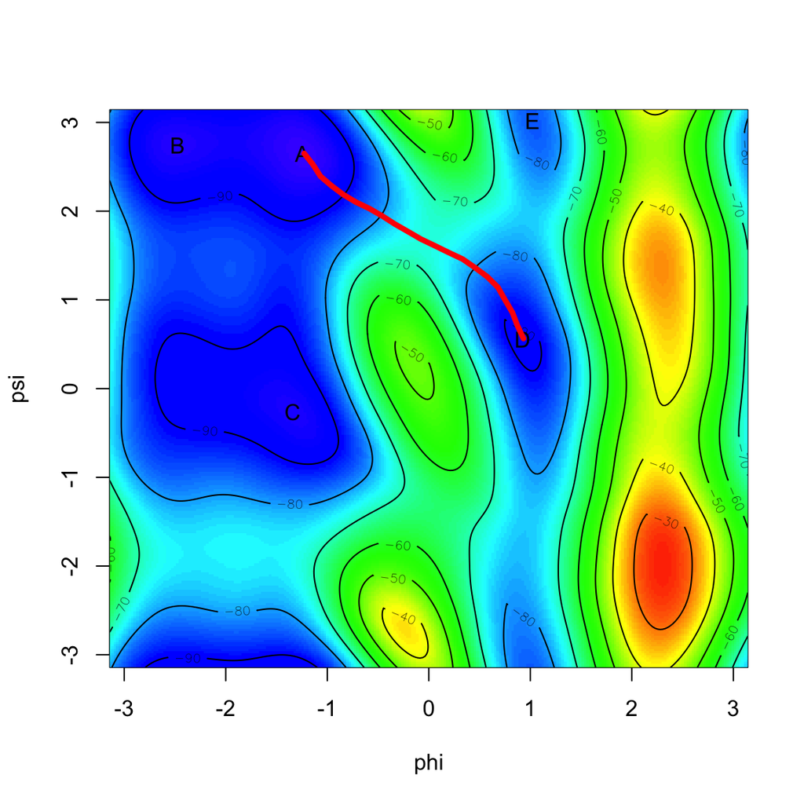

Figure 7: Path of transition from A to D projected onto free energy surface. This represents the most favorable path between these minima. It can be used to identify the transition state (the point with the highest energy on the path) and the rate of the transition.

Let us also briefly present metadynminer3d. This package uses packages rgl and misc3d to plot the free energy surface as an interactive (mouse rotatable) isosurface in the space of three collective variables (see Figure 8). metadynminer3d can produce interactive WebGL visualizations using `writeWebGL` command from the rgl package.

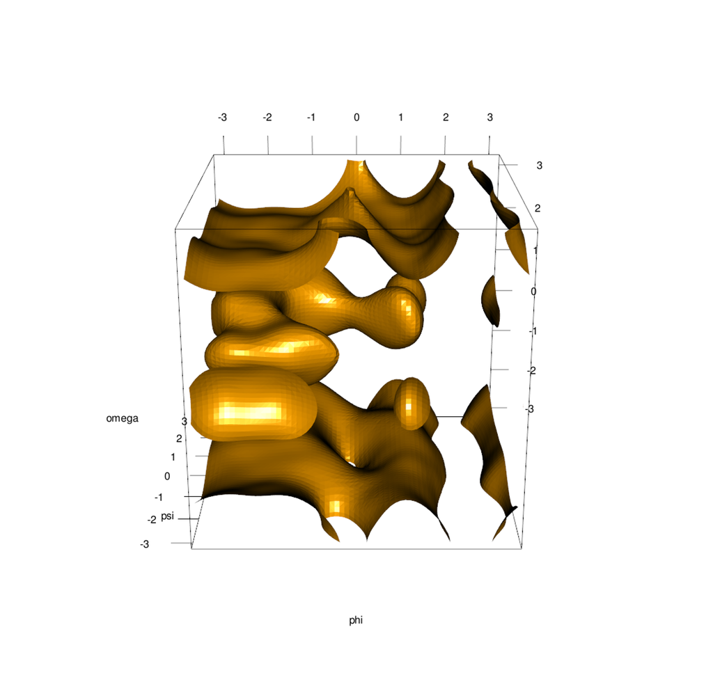

Figure 8: 3D free energy surface depicted as isosurface at -30 kJ/mol. It is analogous to the 2D plot in Figure 4, but with three collective variables.

metadynminer and metadynminer3d were developed to be highly flexible. This flexibility can be demonstrated on two examples. First, it is useful to visualize the progress of metadynamics as a video sequence showing the evolution of the free energy surface. The code to generate corresponding images can be written in metadynminer as:

```
tfes <- fes(hillsfile, tmax=100)
png("snap%04d.png")
plot(tfes, zlim=c(-200,0))
for(i in 1:299) {
  tfes <- tfes+fes(acealanme, imin=100*i+1, imax=100*(i+1))
  plot(tfes, zlim=c(-200,0), xlab="phi", ylab="psi")
}
dev.off()
```

This generates a series of images that can be concatenated by external software to make a video file.